# Lab 2 — La mita minera del Perú

Una frontera que todavía se nota (réplica de Dell, 2010)

Autor/a

Economía del Desarrollo (06230) · Universidad ICESI

Fecha de publicación

13 de agosto de 2026

## 1 De qué se trata

Entre **1573 y 1812**, la Corona española obligó a los pueblos que quedaban **dentro** de un área definida por decreto a enviar **la séptima parte de sus hombres adultos** a trabajar en las minas de **Potosí** y **Huancavelica**. Los pueblos que quedaban **justo afuera** de esa línea quedaron exentos.

La mita se abolió en 1812. La pregunta de Melissa Dell es brutal en su simplicidad:

> **Casi doscientos años después, ¿todavía se nota esa frontera?**

Vamos a replicar su respuesta con los datos originales del paper: hogares de la **ENAHO 2001** del Perú, a menos de 100 km de la frontera de la mita.

**AdvertenciaEl supuesto que sostiene todo: continuidad en la frontera**

A diferencia del Lab 1, acá **sí** vamos a hacer una afirmación causal. Pero descansa entera en un supuesto: que todo lo que determina el consumo —geografía, cultura, historia previa— varía de forma **suave** al cruzar el límite, y que **lo único que salta** es haber estado sujeto a la mita.

Ese supuesto **no se puede probar**. Solo se puede atacar: si algo más salta en el mismo lugar (un límite étnico, un piso ecológico, la frontera de las haciendas), el diseño se cae. En Sección 8 lo ponemos a prueba.

## 2 Preparación

`pacman` instala lo que falte y carga lo que ya esté: una sola línea para todo.

```r
if (!require("pacman")) install.packages("pacman")
pacman::p_load(tidyverse, scales, fixest, rdrobust, broom)

hogares <- read_rds("datos/dell_mita_hogares.rds") |>
  as_tibble()

distritos <- read_rds("datos/dell_mita_distritos.rds") |>
  as_tibble()
```

Dos archivos: **hogares** (1.478 hogares de la ENAHO 2001, la muestra de la Tabla II del paper) y **distritos** (299 distritos, para el mapa y para el balance histórico).

## 3 Una mirada a los datos

```r
dim(hogares)
```

```
[1] 1478   18
```

```r
hogares |>
  group_by(mita) |>
  summarise(hogares = n(), distritos = n_distinct(distrito))
```

| mita | hogares | distritos |
| --- | --- | --- |
| 0 | 366 | 20 |
| 1 | 1112 | 51 |

Las tres variables que importan:

- `mita` — el **tratamiento**: 1 si el distrito estuvo sujeto al reclutamiento forzoso.
- `lhhequiv` — el **resultado**: log del consumo del hogar por adulto equivalente.
- `dist_frontera` — la **variable de asignación**: distancia a la frontera en km, con signo. Negativa fuera de la mita, positiva dentro.

```r
hogares |>
  group_by(mita) |>
  summarise(minimo = min(dist_frontera), maximo = max(dist_frontera))
```

| mita | minimo | maximo |
| --- | --- | --- |
| 0 | -80.971596 | -6.047964 |
| 1 | 4.246131 | 98.507965 |

El tratamiento cambia **de golpe** en `dist_frontera = 0`. Todo lo demás debería cambiar de forma suave. Ese contraste es todo el diseño.

## 4 El mapa

> **La idea del RDD geográfico:** no comparamos el Perú de la mita con el Perú sin mita. Comparamos vecinos separados por una línea trazada en un despacho colonial.

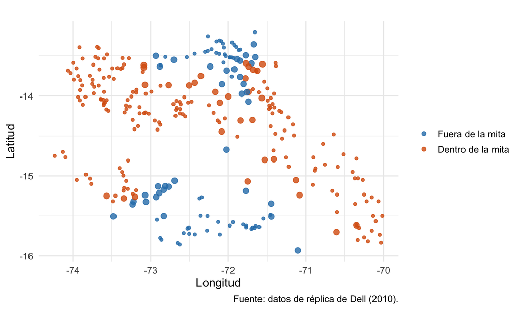

Figura 1: Distritos del sur del Perú. Los puntos grandes tocan la frontera de la mita.

```r
distritos <- distritos |>
  mutate(grupo = factor(mita,
                        levels = c(0, 1),
                        labels = c("Fuera de la mita", "Dentro de la mita")))

ggplot(distritos, aes(lon, lat, color = grupo)) +
  geom_point(aes(size = frontera == 1), alpha = 0.8) +
  scale_size_manual(values = c(`FALSE` = 1.3, `TRUE` = 2.6), guide = "none") +
  scale_color_manual(values = c("Fuera de la mita" = "#2c7fb8",
                                "Dentro de la mita" = "#d95f0e")) +
  coord_quickmap() +
  labs(x = "Longitud", y = "Latitud", color = NULL,
       caption = "Fuente: datos de réplica de Dell (2010).") +
  theme_minimal(base_size = 13)
```

La zona de mita (naranja) es una banda que corre de noroeste a sureste, hacia Potosí. Los distritos azules del norte y del sur quedaron fuera. **La comparación válida ocurre solo donde los dos colores se tocan.**

## 5 El salto en el consumo

Promediamos el consumo en bins de 10 km a cada lado y buscamos un **escalón** en cero. Esta es *la* imagen que hay que saber leer en un RDD.

```r
resumen_bins <- hogares |>
  mutate(bin = floor(dist_frontera / 10) * 10 + 5) |>   # centro del bin de 10 km
  group_by(bin, mita) |>
  summarise(consumo = mean(lhhequiv), hogares = n(), .groups = "drop")

head(resumen_bins)
```

| bin | mita | consumo | hogares |
| --- | --- | --- | --- |
| -85 | 0 | 6.899192 | 14 |
| -75 | 0 | 6.636863 | 22 |
| -45 | 0 | 5.799275 | 27 |
| -35 | 0 | 6.390479 | 13 |
| -25 | 0 | 5.884716 | 112 |
| -15 | 0 | 5.826363 | 79 |

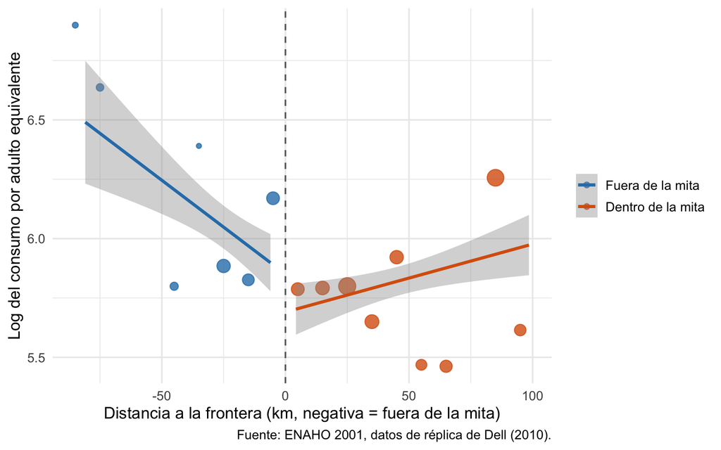

Figura 2: Consumo promedio por bin de 10 km. El tamaño del punto es el número de hogares.

```r
ggplot(resumen_bins, aes(bin, consumo)) +
  geom_vline(xintercept = 0, linetype = "dashed", color = "grey40") +
  geom_point(aes(size = hogares, color = factor(mita)), alpha = 0.8) +
  geom_smooth(data = hogares, aes(dist_frontera, lhhequiv, color = factor(mita)),
              method = "lm", formula = y ~ x, se = TRUE) +
  scale_color_manual(values = c("0" = "#2c7fb8", "1" = "#d95f0e"),
                     labels = c("Fuera de la mita", "Dentro de la mita")) +
  scale_size_continuous(range = c(1.5, 6), guide = "none") +
  labs(x = "Distancia a la frontera (km, negativa = fuera de la mita)",
       y = "Log del consumo por adulto equivalente", color = NULL,
       caption = "Fuente: ENAHO 2001, datos de réplica de Dell (2010).") +
  theme_minimal(base_size = 13)
```

Hay un escalón hacia abajo al entrar a la zona de mita. Ahora hay que medirlo.

## 6 La estimación

Dell controla la geografía con un **polinomio cúbico en longitud y latitud**, más elevación, pendiente y composición del hogar. Y agrega **efectos fijos de segmento de frontera** (`bfe4_*`): la frontera se parte en cuatro tramos, de modo que la comparación sea *a lo largo* de la línea y no entre regiones distintas del país.

Los errores estándar se agrupan por **distrito**: los hogares de un mismo distrito comparten geografía y tratamiento.

Primero definimos las tres ventanas alrededor de la frontera que usa el paper:

```r
hogares_100 <- hogares |> filter(d_bnd < 100)
hogares_75  <- hogares |> filter(d_bnd < 75)
hogares_50  <- hogares |> filter(d_bnd < 50)
```

Y corremos la regresión principal —la columna 1 del Panel A:

```r
m_latlon_100 <- feols(
  lhhequiv ~ mita +
    x + y + I(x^2) + I(y^2) + I(x * y) + I(x^3) + I(y^3) + I(x^2 * y) + I(x * y^2) +
    elv_sh + slope + infants + children + adults + bfe4_1 + bfe4_2 + bfe4_3,
  data = hogares_100,
  cluster = ~distrito
)

# tidy() saca la tabla de coeficientes como un tibble; nos quedamos con la mita.
tidy(m_latlon_100) |>
  filter(term == "mita")
```

| term | estimate | std.error | statistic | p.value |
| --- | --- | --- | --- | --- |
| mita | -0.2841148 | 0.1988987 | -1.42844 | 0.1576123 |

Como el resultado está en logaritmos, el coeficiente se traduce a porcentaje con `exp(b) - 1`:

```r
efecto_principal <- tidy(m_latlon_100) |>
  filter(term == "mita") |>
  mutate(
    efecto_pct = (exp(estimate) - 1) * 100,
    hogares    = nobs(m_latlon_100),
    distritos  = n_distinct(hogares_100$distrito)
  ) |>
  select(coeficiente = estimate, ee = std.error, efecto_pct, hogares, distritos)

efecto_principal
```

| coeficiente | ee | efecto_pct | hogares | distritos |
| --- | --- | --- | --- | --- |
| -0.2841148 | 0.1988987 | -24.73197 | 1478 | 71 |

**Un hogar de un distrito que estuvo sujeto a la mita consume cerca de un 25 % menos que su vecino del otro lado de la frontera**, casi doscientos años después de abolida la institución. Es exactamente el número del paper.

Note que el coeficiente **no es estadísticamente significativo**. Eso también está en Dell: con 71 distritos y un polinomio bidimensional flexible, la estimación es imprecisa. El paper lo dice explícitamente.

## 7 ¿Aguanta el resultado?

> **La lección incómoda:** un RDD no es un botón. Usted elige cómo controlar la geografía y qué tan cerca de la frontera mirar. Si el resultado depende de esas elecciones, no es un resultado.

Dell reporta tres formas de controlar la geografía × tres ventanas. Corremos las nueve regresiones, una por una, para que se vea exactamente qué cambia entre ellas: **solo el polinomio de geografía y la muestra**.

### 7.1 Cúbica en latitud y longitud

`m_latlon_100` ya quedó estimado arriba; faltan las otras dos ventanas.

```r
m_latlon_75 <- feols(
  lhhequiv ~ mita +
    x + y + I(x^2) + I(y^2) + I(x * y) + I(x^3) + I(y^3) + I(x^2 * y) + I(x * y^2) +
    elv_sh + slope + infants + children + adults + bfe4_1 + bfe4_2 + bfe4_3,
  data = hogares_75, cluster = ~distrito
)

m_latlon_50 <- feols(
  lhhequiv ~ mita +
    x + y + I(x^2) + I(y^2) + I(x * y) + I(x^3) + I(y^3) + I(x^2 * y) + I(x * y^2) +
    elv_sh + slope + infants + children + adults + bfe4_1 + bfe4_2 + bfe4_3,
  data = hogares_50, cluster = ~distrito
)
```

### 7.2 Cúbica en la distancia a Potosí

```r
m_potosi_100 <- feols(
  lhhequiv ~ mita + dpot + I(dpot^2) + I(dpot^3) +
    elv_sh + slope + infants + children + adults + bfe4_1 + bfe4_2 + bfe4_3,
  data = hogares_100, cluster = ~distrito
)

m_potosi_75 <- feols(
  lhhequiv ~ mita + dpot + I(dpot^2) + I(dpot^3) +
    elv_sh + slope + infants + children + adults + bfe4_1 + bfe4_2 + bfe4_3,
  data = hogares_75, cluster = ~distrito
)

m_potosi_50 <- feols(
  lhhequiv ~ mita + dpot + I(dpot^2) + I(dpot^3) +
    elv_sh + slope + infants + children + adults + bfe4_1 + bfe4_2 + bfe4_3,
  data = hogares_50, cluster = ~distrito
)
```

### 7.3 Cúbica en la distancia a la frontera

```r
m_frontera_100 <- feols(
  lhhequiv ~ mita + d_bnd + I(d_bnd^2) + I(d_bnd^3) +
    elv_sh + slope + infants + children + adults + bfe4_1 + bfe4_2 + bfe4_3,
  data = hogares_100, cluster = ~distrito
)

m_frontera_75 <- feols(
  lhhequiv ~ mita + d_bnd + I(d_bnd^2) + I(d_bnd^3) +
    elv_sh + slope + infants + children + adults + bfe4_1 + bfe4_2 + bfe4_3,
  data = hogares_75, cluster = ~distrito
)

m_frontera_50 <- feols(
  lhhequiv ~ mita + d_bnd + I(d_bnd^2) + I(d_bnd^3) +
    elv_sh + slope + infants + children + adults + bfe4_1 + bfe4_2 + bfe4_3,
  data = hogares_50, cluster = ~distrito
)
```

### 7.4 Los nueve resultados en una sola tabla

A cada `tidy()` le pegamos la etiqueta de qué modelo es, y luego apilamos con `bind_rows()`. De cada modelo nos quedamos únicamente con la fila de `mita`.

```r
rejilla <- bind_rows(
  tidy(m_latlon_100)   |> mutate(especificacion = "Cúbica en lat-lon",        ventana = 100, n = nobs(m_latlon_100)),
  tidy(m_latlon_75)    |> mutate(especificacion = "Cúbica en lat-lon",        ventana = 75,  n = nobs(m_latlon_75)),
  tidy(m_latlon_50)    |> mutate(especificacion = "Cúbica en lat-lon",        ventana = 50,  n = nobs(m_latlon_50)),
  tidy(m_potosi_100)   |> mutate(especificacion = "Cúbica en dist. Potosí",   ventana = 100, n = nobs(m_potosi_100)),
  tidy(m_potosi_75)    |> mutate(especificacion = "Cúbica en dist. Potosí",   ventana = 75,  n = nobs(m_potosi_75)),
  tidy(m_potosi_50)    |> mutate(especificacion = "Cúbica en dist. Potosí",   ventana = 50,  n = nobs(m_potosi_50)),
  tidy(m_frontera_100) |> mutate(especificacion = "Cúbica en dist. frontera", ventana = 100, n = nobs(m_frontera_100)),
  tidy(m_frontera_75)  |> mutate(especificacion = "Cúbica en dist. frontera", ventana = 75,  n = nobs(m_frontera_75)),
  tidy(m_frontera_50)  |> mutate(especificacion = "Cúbica en dist. frontera", ventana = 50,  n = nobs(m_frontera_50))
) |>
  filter(term == "mita") |>
  select(especificacion, ventana,
         coef = estimate, ee = std.error, p = p.value, n) |>
  mutate(coef = round(coef, 3), ee = round(ee, 3), p = round(p, 3))

rejilla
```

| especificacion | ventana | coef | ee | p | n |
| --- | --- | --- | --- | --- | --- |
| Cúbica en lat-lon | 100 | -0.284 | 0.199 | 0.158 | 1478 |
| Cúbica en lat-lon | 75 | -0.216 | 0.207 | 0.301 | 1161 |
| Cúbica en lat-lon | 50 | -0.331 | 0.219 | 0.137 | 1013 |
| Cúbica en dist. Potosí | 100 | -0.337 | 0.087 | 0.000 | 1478 |
| Cúbica en dist. Potosí | 75 | -0.307 | 0.101 | 0.003 | 1161 |
| Cúbica en dist. Potosí | 50 | -0.329 | 0.096 | 0.001 | 1013 |
| Cúbica en dist. frontera | 100 | -0.277 | 0.078 | 0.001 | 1478 |
| Cúbica en dist. frontera | 75 | -0.230 | 0.089 | 0.012 | 1161 |
| Cúbica en dist. frontera | 50 | -0.224 | 0.092 | 0.019 | 1013 |

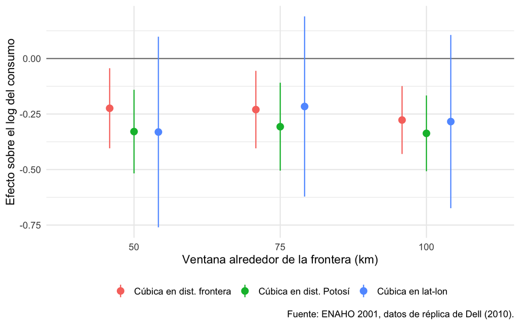

Figura 3: Coeficiente de la mita e intervalo al 95 %, por especificación y ventana.

```r
ggplot(rejilla, aes(factor(ventana), coef, color = especificacion)) +
  geom_hline(yintercept = 0, color = "grey50") +
  geom_pointrange(aes(ymin = coef - 1.96 * ee, ymax = coef + 1.96 * ee),
                  position = position_dodge(width = 0.5)) +
  labs(x = "Ventana alrededor de la frontera (km)",
       y = "Efecto sobre el log del consumo", color = NULL,
       caption = "Fuente: ENAHO 2001, datos de réplica de Dell (2010).") +
  theme_minimal(base_size = 13) +
  theme(legend.position = "bottom")
```

Los nueve coeficientes caen entre **−0,34 y −0,22** (es decir, entre −29 % y −20 %). El efecto no depende de la especificación. Y con las dos cúbicas unidimensionales —que usan menos grados de libertad— el efecto **sí** resulta significativo.

### 7.5 El estimador moderno: `rdrobust`

`rdrobust` ajusta rectas locales a cada lado de la frontera y elige el **ancho de banda óptimo** por el criterio CCT. Es el estándar hoy. Acá conviene usarlo con cabeza.

Ojo: `rdrobust` no trabaja con tibbles, pide vectores y una matriz de covariables.

```r
covariables <- hogares |>
  select(elv_sh, slope, infants, children, adults, bfe4_1, bfe4_2, bfe4_3) |>
  as.matrix()

rd_auto <- rdrobust(hogares$lhhequiv, hogares$dist_frontera, c = 0,
                    covs = covariables, cluster = hogares$distrito)

rd_50 <- rdrobust(hogares$lhhequiv, hogares$dist_frontera, c = 0,
                  covs = covariables, cluster = hogares$distrito, h = 50)

comparacion_rd <- tibble(
  version = c("Ancho de banda óptimo (CCT)", "Ancho de banda fijo, 50 km"),
  h_km    = round(c(rd_auto$bws[1, 1], 50), 1),
  coef    = round(c(rd_auto$coef[1], rd_50$coef[1]), 3),
  ee      = round(c(rd_auto$se[1], rd_50$se[1]), 3),
  n_izq   = c(rd_auto$N_h[1], rd_50$N_h[1]),
  n_der   = c(rd_auto$N_h[2], rd_50$N_h[2])
)

comparacion_rd
```

| version | h_km | coef | ee | n_izq | n_der |
| --- | --- | --- | --- | --- | --- |
| Ancho de banda óptimo (CCT) | 10 | -5.448 | 0.851 | 99 | 101 |
| Ancho de banda fijo, 50 km | 50 | -0.335 | 0.229 | 330 | 683 |

**ImportantePor qué el ancho de banda automático se equivoca acá**

La distancia a la frontera está medida **a nivel de distrito**, no de hogar: la variable de asignación solo toma **71 valores distintos**. El algoritmo CCT elige unos 10 km, y a esa distancia quedan un puñado de distritos por lado — el ajuste local explota y produce un coeficiente absurdo.

El algoritmo no sabe de dónde salieron los datos. **Usted sí.** Con una ventana razonable, `rdrobust` vuelve a dar lo mismo que Dell.

## 8 ¿Es creíble la frontera?

El supuesto de continuidad no se prueba, pero sí se ataca. Si algo que **no** es la mita salta en la frontera, el diseño está en problemas. La receta es la misma de siempre, cambiando lo que va a la izquierda del `~`.

### 8.1 La geografía de hoy

```r
m_balance_elevacion <- feols(
  elv_sh ~ mita +
    x + y + I(x^2) + I(y^2) + I(x * y) + I(x^3) + I(y^3) + I(x^2 * y) + I(x * y^2) +
    bfe4_1 + bfe4_2 + bfe4_3,
  data = hogares_100, cluster = ~distrito
)

m_balance_pendiente <- feols(
  slope ~ mita +
    x + y + I(x^2) + I(y^2) + I(x * y) + I(x^3) + I(y^3) + I(x^2 * y) + I(x * y^2) +
    bfe4_1 + bfe4_2 + bfe4_3,
  data = hogares_100, cluster = ~distrito
)

balance_geo <- bind_rows(
  tidy(m_balance_elevacion) |> mutate(variable = "elv_sh"),
  tidy(m_balance_pendiente) |> mutate(variable = "slope")
) |>
  filter(term == "mita") |>
  select(variable, coef = estimate, ee = std.error, p = p.value)

balance_geo
```

| variable | coef | ee | p |
| --- | --- | --- | --- |
| elv_sh | 0.039017 | 0.1246611 | 0.7552229 |
| slope | -1.901305 | 1.3200688 | 0.1542383 |

### 8.2 La prueba fuerte: el censo de Toledo de 1572

El virrey Toledo levantó un censo en **1572**, un año **antes** de que empezara la mita. Si los distritos de mita ya eran distintos entonces, la frontera nunca fue “como aleatoria” y todo el diseño se cae.

Acá la unidad es el **distrito**, no el hogar: son 109 distritos con registro.

```r
distritos_1572 <- distritos |>
  filter(d_bnd < 100, !is.na(sh_trib))

m_pre_tributarios <- feols(
  sh_trib ~ mita +
    x + y + I(x^2) + I(y^2) + I(x * y) + I(x^3) + I(y^3) + I(x^2 * y) + I(x * y^2) +
    elv_sh + slope + bfe4_1 + bfe4_2 + bfe4_3,
  data = distritos_1572, vcov = "hetero"
)

m_pre_ninos <- feols(
  sh_boys ~ mita +
    x + y + I(x^2) + I(y^2) + I(x * y) + I(x^3) + I(y^3) + I(x^2 * y) + I(x * y^2) +
    elv_sh + slope + bfe4_1 + bfe4_2 + bfe4_3,
  data = distritos_1572, vcov = "hetero"
)

m_pre_mujeres <- feols(
  sh_women ~ mita +
    x + y + I(x^2) + I(y^2) + I(x * y) + I(x^3) + I(y^3) + I(x^2 * y) + I(x * y^2) +
    elv_sh + slope + bfe4_1 + bfe4_2 + bfe4_3,
  data = distritos_1572, vcov = "hetero"
)

balance_1572 <- bind_rows(
  tidy(m_pre_tributarios) |> mutate(variable = "sh_trib",  n = nobs(m_pre_tributarios)),
  tidy(m_pre_ninos)       |> mutate(variable = "sh_boys",  n = nobs(m_pre_ninos)),
  tidy(m_pre_mujeres)     |> mutate(variable = "sh_women", n = nobs(m_pre_mujeres))
) |>
  filter(term == "mita") |>
  select(variable, coef = estimate, ee = std.error, p = p.value, n)

balance_1572
```

| variable | coef | ee | p | n |
| --- | --- | --- | --- | --- |
| sh_trib | 0.0049059 | 0.0096278 | 0.6115681 | 109 |
| sh_boys | -0.0097807 | 0.0105582 | 0.3566588 | 109 |
| sh_women | -0.0114847 | 0.0137994 | 0.4073950 | 109 |

Juntamos los dos bloques para graficarlos en el mismo eje. Dividimos `coef / ee` para obtener el **estadístico t**: así variables medidas en unidades distintas quedan comparables.

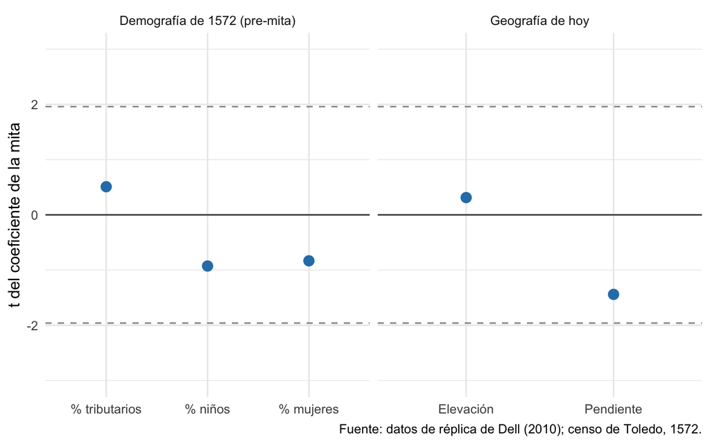

Figura 4: Estadístico t del salto en la frontera. Entre las líneas punteadas, el salto no es significativo.

```r
etiquetas <- c(elv_sh = "Elevación", slope = "Pendiente",
               sh_trib = "% tributarios", sh_boys = "% niños", sh_women = "% mujeres")

balance <- bind_rows(
  balance_geo  |> mutate(bloque = "Geografía de hoy"),
  balance_1572 |> mutate(bloque = "Demografía de 1572 (pre-mita)")
) |>
  mutate(
    etiqueta = factor(etiquetas[variable], levels = etiquetas),
    t = coef / ee
  )

ggplot(balance, aes(etiqueta, t)) +
  geom_hline(yintercept = c(-1.96, 1.96), linetype = "dashed", color = "grey60") +
  geom_hline(yintercept = 0, color = "grey30") +
  geom_point(size = 3.5, color = "#2c7fb8") +
  facet_wrap(~ bloque, scales = "free_x") +
  coord_cartesian(ylim = c(-3, 3)) +
  labs(x = NULL, y = "t del coeficiente de la mita",
       caption = "Fuente: datos de réplica de Dell (2010); censo de Toledo, 1572.") +
  theme_minimal(base_size = 13)
```

**Nada más salta.** Ni la elevación ni la pendiente de hoy, ni la composición demográfica de 1572. Es la mejor defensa del diseño que permiten estos datos.

## 9 ¿Por qué persiste? El mecanismo

El resultado es desconcertante: la mita se abolió en 1812 y su huella sigue ahí en 2001. ¿Por qué canal viaja doscientos años? El argumento de Dell, en cuatro pasos:

1. **Haciendas.** Fuera de la mita se formaron grandes haciendas. Dentro, la Corona lo impidió para no competir por la mano de obra que necesitaba en las minas. Hoy hay **menos** tierra en manos de propietarios grandes en los distritos de mita.
2. **Bienes públicos.** Los hacendados tenían poder político y capital para exigirle al Estado carreteras y escuelas. Las comunidades campesinas dispersas, no. Dell encuentra **1,5 años menos de escolaridad** en zonas de mita en 2001 (su Tabla VII).
3. **Caminos.** Los distritos de mita quedaron **peor conectados** a la red vial (su Tabla VIII).
4. **Mercado.** Sin caminos, los hogares venden menos y producen para autoconsumo: agricultura de **subsistencia** en vez de participación en el mercado (su Tabla IX).

La mita no dejó una herida directa que se transmitiera de padres a hijos. **Empujó a la región por un camino institucional distinto, y ese camino se reprodujo solo.**

## 10 Síntesis y discusión

- Los hogares de distritos sujetos a la mita consumen **cerca de 25 % menos** que sus vecinos del otro lado de la frontera, casi dos siglos después de abolida la institución (Sección 6).
- El resultado **sobrevive** a tres formas de controlar la geografía y a tres ventanas (Sección 7): no es un artefacto de la especificación.
- **Nada más salta** en la frontera: ni la geografía de hoy, ni la demografía de 1572 (Sección 8). Eso es lo que sostiene la lectura causal.

**NotaPara discutir en clase**

1. ¿Por qué deberíamos creer que esto es causal? Enuncie el supuesto de continuidad con sus palabras y proponga **una** cosa concreta que lo rompería. ¿El balance de 1572 la descarta, o no la toca?
2. Este es un efecto **local**, en la frontera. ¿Por qué *no* podemos decir “la mita redujo el consumo del Perú en 25 %”? ¿A quién se parecen los distritos del borde?
3. En Sección 7, el efecto es significativo con las cúbicas unidimensionales pero no con la cúbica en lat-lon. ¿Cuál reportaría usted, y por qué? ¿Qué haría un lector malintencionado con esa libertad?
4. El ancho de banda automático de `rdrobust` dio una cifra absurda. ¿Qué dice eso sobre usar herramientas estadísticas sin mirar de dónde vienen los datos?

*Datos: paquete de réplica de Dell, M. (2010), “The Persistent Effects of Peru’s Mining Mita”, Econometrica 78(6), 1863–1903. Muestra de hogares vía MIT OpenCourseWare 14.75 (CC BY-NC-SA 4.0). Ver `datos/SOURCE.md`.*